# Code for the calculation of bipartite network metrics in the whole parasite community of Planiliza haematocheilus for the Sea of Azov and Sea of Japan

Mar Llaberia-Robledillo, Juan A. Balbuena, Volodimir Sarabeev, Cristina Llopis-Belenguer

# Libraries

Load the libraries required.

```r
library(bipartite)
library(parallel)
```

# Data

## Set a working directory

Optional but very useful step when you are working with multiple data files. It allows you to call files without writing their path, in addition to allowing data to be stored in the same folder, the working directory.

```r
#setwd("~/Desktop/Planiliza haematocheilus (Lh)/whole")
```

## Host-parasite abundance data

The main data necessary for the analysis belongs to a database of helminth parasites of the grey mullets (see main text for description). First, we edit the matrices separating those P. haematocheilus individuals belonging to the Sea of Azov - Black Sea and those belonging to the Sea of Japan. Second, we eliminate those data that are not necessary for our study (date, season, sex, etc.). Third, the data are divided according to the transmission strategy of the parasite species: ectoparasites, actively transmitted parasites, trophically transmitted parasites and finally, the whole community. This code shows the whole parasite community analysis. We upload the host-parasite abundance matrices once arranged.

```r
azov_whole<- read.table("azov_whole.txt", header = T, row.names = 1)
japan_whole<- read.table("japan_whole.txt", header = T, row.names = 1)
```

## Real values of the Azov and Japan networks

### Bootstrap values

We generate 1,000 random networks from each matrix with replacement, row-based bootstrap replicas, and a fixed number of individuals. Then, we calculate the values of the indices for each of the replicated networks.

### Nullmodel values

We generate 1,000 replicas of the network matrices with the null.model function, with the swap.web and vaznull algorithms. Then, we calculate the values of the indices for each of the generated networks.

## Standardize the real values of the network and the values of the null model

We standardized the real values of the networks and the values obtained from the 1,000 bootstrap networks of the WNODF and Q indices.

```r
# SEA OF AZOV
## WNODF values
index_whole_azov [,2] #real value
```

```
## [1] 29.07485
```

```r
boot_whole_azov [,2] #bootstrap values
```

```
##    [1] 26.95091 29.30880 28.76286 28.68332 31.49933 30.76938 27.02008 29.05446
##    [9] 29.52792 28.35051 29.07614 28.37454 28.03207 29.39904 28.43800 28.63791
##   [17] 29.19859 28.31981 30.21805 29.25995 29.63538 27.93668 27.28472 30.34635
##   [25] 31.54299 29.50772 27.71244 28.73627 27.32040 28.50030 29.03463 30.14453
##   [33] 30.88518 28.43316 28.63278 30.30994 30.59333 27.66562 29.93341 28.25442
##   [41] 28.69025 29.37675 28.22340 27.29662 29.33718 29.95682 28.24976 28.75801
##   [49] 29.50741 29.51139 27.85948 30.00058 29.52390 27.31676 31.49760 28.92359
##   [57] 27.41923 26.54634 27.29649 30.14459 29.61746 31.27483 28.98466 28.40367
##   [65] 28.60625 31.26830 28.38376 27.94302 29.11445 28.04624 28.03265 30.11707
##   [73] 30.32305 32.32968 30.35412 29.93251 29.49287 28.80119 29.68061 28.44042
##   [81] 29.80639 29.20604 28.35255 27.29059 30.23000 30.39914 29.30421 30.18748
##   [89] 28.28333 28.35075 30.03975 29.75757 28.86981 30.70408 29.24830 29.80653
##   [97] 28.79874 29.24338 28.71032 27.71580 30.45978 26.91604 26.20641 29.94137
##  [105] 28.99114 28.17673 28.72600 27.02181 30.34442 25.43253 31.46841 30.47467
##  [113] 27.65650 28.97950 28.28409 29.07808 29.23199 26.74289 29.90505 28.84336
```

[output cut: 110 more lines]

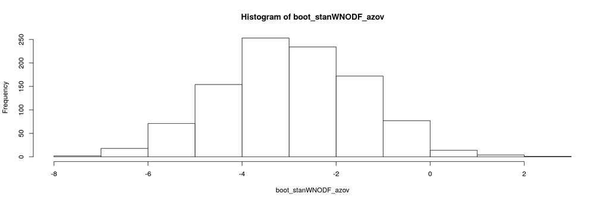

```r
# formula to standardize the networks values
stan_WNODF  <- function (x) {
  mean <- mean(null_swap_whole_azov[,1])
  sd <- sd(null_swap_whole_azov[,1])
  y <- (x)
  result <- (y-mean)/sd
}
a_w_value_wnodf <- sapply(index_whole_azov[,2], stan_WNODF) #real standardized value
boot_stanWNODF_azov <- as.numeric(sapply(boot_whole_azov[,2], stan_WNODF)) #bootstrap standardized values
#write.csv2(boot_stanWNODF_azov, file = "boot_stanWNODF_azov.csv")
hist(boot_stanWNODF_azov)
```

```r
## Q VALUES
index_whole_azov [,3] #real value
```

```
## [1] 0.5681022
```

```r
boot_whole_azov [,3] #bootstrap values
```

```
##    [1] 0.5794887 0.5307806 0.5220121 0.5593801 0.4644134 0.4948502 0.5053498
##    [8] 0.5571975 0.5175480 0.5593731 0.5539556 0.5733713 0.5974006 0.5495284
##   [15] 0.5733226 0.5636082 0.5327498 0.5679296 0.5738771 0.5239381 0.5693465
##   [22] 0.5491812 0.5906150 0.5797123 0.4493416 0.5629189 0.5955095 0.5456484
##   [29] 0.5273602 0.4886218 0.5491981 0.5740743 0.5108430 0.6020961 0.5548717
##   [36] 0.5209925 0.5636296 0.5040112 0.5726459 0.5243287 0.4891973 0.6014769
##   [43] 0.5834057 0.5776720 0.5713722 0.5016935 0.5022912 0.5839411 0.6023019
##   [50] 0.5479265 0.5087241 0.4924171 0.5535626 0.5714181 0.5603451 0.4845263
##   [57] 0.5543889 0.4712276 0.5840468 0.5215173 0.5855024 0.5347455 0.5911946
##   [64] 0.5585425 0.6108057 0.5934166 0.5226600 0.5404106 0.5493104 0.5376297
##   [71] 0.5670606 0.5446175 0.5644686 0.5597682 0.5995808 0.5057827 0.5941410
##   [78] 0.5989050 0.5249501 0.5412824 0.5757565 0.5640991 0.5705703 0.5896062
##   [85] 0.5398249 0.5197182 0.5014026 0.5022863 0.5637145 0.5495605 0.5558391
##   [92] 0.5552379 0.5960671 0.5247195 0.5720106 0.5911083 0.6042309 0.5654568
##   [99] 0.5920441 0.5666725 0.5745899 0.6077745 0.5668855 0.5572681 0.5927792
```

[output cut: 128 more lines]

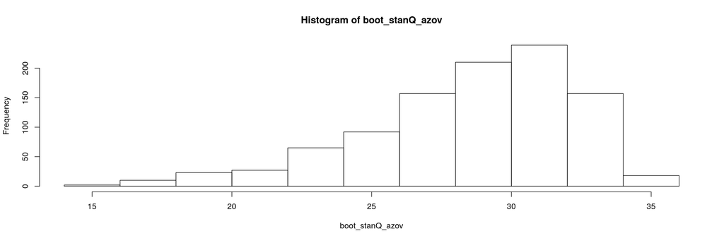

```r
stan_Q  <- function (x) {
  mean <- mean(null_swap_whole_azov[,2])
  sd <- sd(null_swap_whole_azov[,2])
  y <- (x)
  result <- (y-mean)/sd
}
a_w_value_q <- sapply(index_whole_azov[,3], stan_Q) #real standardized value
boot_stanQ_azov <- as.numeric(sapply(boot_whole_azov[,3], stan_Q)) #bootstrap standardized values
#write.csv2(boot_stanQ_azov, file = "boot_stanQ_azov.csv")
hist(boot_stanQ_azov)
```

```r
# SEA OF JAPAN
## WNODF VALUES
index_whole_japan [,2] #real value
```

```
## [1] 34.21425
```

```r
boot_whole_japan [,2] #bootstrap values
```

```
##    [1] 33.51644 33.91985 36.60522 36.37867 33.59712 31.98254 32.23862 34.76550
##    [9] 30.99848 34.05666 34.36746 34.82744 31.94566 33.25640 35.24545 32.66573
##   [17] 34.84979 34.10581 33.40628 35.61279 31.53193 33.47214 33.48938 34.90589
##   [25] 35.89653 34.19178 33.45838 33.30926 36.58303 33.89132 34.21603 35.30649
##   [33] 35.54829 33.03027 33.15271 32.25401 35.03278 33.82541 35.13708 34.17662
##   [41] 33.40762 34.53860 33.59008 34.51117 34.96476 33.93357 32.59076 34.75850
##   [49] 33.86993 32.67910 35.76194 34.68421 34.88378 36.47382 31.11254 33.57510
##   [57] 35.25653 32.38263 32.62668 31.61682 33.08769 35.45317 31.03616 35.12180
##   [65] 34.71170 33.60902 36.11014 32.05451 34.26682 31.58262 34.60472 34.85924
##   [73] 32.23479 33.04362 33.74415 34.06935 34.26265 34.05874 36.91079 33.75373
##   [81] 37.54941 32.63540 32.85991 34.94909 36.08570 33.71088 35.11475 31.93784
##   [89] 36.98432 32.98598 35.20066 33.43332 33.28165 34.64816 35.16137 35.96907
##   [97] 35.78478 35.72333 33.24828 35.97814 36.69635 33.43857 33.84101 36.70077
##  [105] 34.09532 33.96177 34.18583 32.31341 34.18406 34.07058 33.21449 33.18451
##  [113] 32.30590 33.39157 34.23053 34.62964 33.84194 35.58140 32.81189 34.44939
```

[output cut: 110 more lines]

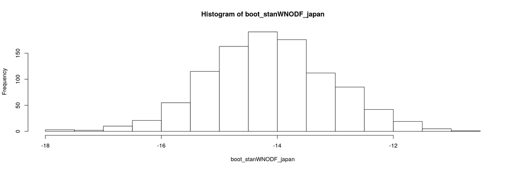

```r
stan_WNODF  <- function (x) {
  mean <- mean(null_swap_whole_japan[,1])
  sd <- sd(null_swap_whole_japan[,1])
  y <- (x)
  result <- (y-mean)/sd
}
j_w_value_wnodf <- sapply(index_whole_japan[,2], stan_WNODF) #real standardized value
boot_stanWNODF_japan <- as.numeric(sapply(boot_whole_japan[,2], stan_WNODF)) #bootstrap standardized values
#write.csv2(boot_stanWNODF_japan, file = "boot_stanWNODF_japan.csv")
hist(boot_stanWNODF_japan)
```

```r
## Q VALUES
index_whole_japan [,3] #real value
```

```
## [1] 0.3758438
```

```r
boot_whole_japan [,3] #bootstrap values
```

```
##    [1] 0.3279184 0.4035359 0.3957683 0.3432261 0.4009021 0.3949939 0.2558696
##    [8] 0.3831403 0.3306653 0.3607335 0.3871751 0.3616480 0.3640864 0.3828052
##   [15] 0.4077592 0.4049640 0.3926858 0.3573247 0.3610877 0.3909535 0.3759650
##   [22] 0.3222115 0.3362530 0.3715411 0.3515847 0.3181829 0.3448417 0.3599853
##   [29] 0.3141479 0.4000389 0.4021893 0.3310998 0.4296932 0.2756363 0.4116292
##   [36] 0.3499148 0.4132802 0.4119586 0.3864767 0.3296979 0.3375488 0.3213132
##   [43] 0.4443372 0.3629682 0.3533354 0.4284841 0.3273913 0.3051428 0.4044587
##   [50] 0.3767553 0.3265598 0.3449149 0.2941747 0.3971702 0.3474537 0.4192344
##   [57] 0.3682311 0.3716874 0.3650718 0.3402060 0.4276946 0.3670036 0.4140631
##   [64] 0.3768755 0.3915854 0.3898215 0.2932698 0.3988432 0.3860943 0.3135778
##   [71] 0.3761213 0.3526634 0.3776375 0.3766534 0.3251303 0.3355720 0.3364105
##   [78] 0.3830000 0.3869895 0.4081390 0.3535239 0.3691476 0.4062234 0.3309058
##   [85] 0.3274039 0.4038013 0.3487597 0.3284097 0.3522234 0.3299933 0.3827000
##   [92] 0.3908278 0.3872474 0.3697921 0.3992242 0.3650280 0.3961448 0.3483172
##   [99] 0.4030141 0.3885423 0.3388282 0.3584223 0.3432143 0.3548524 0.3463002
```

[output cut: 128 more lines]

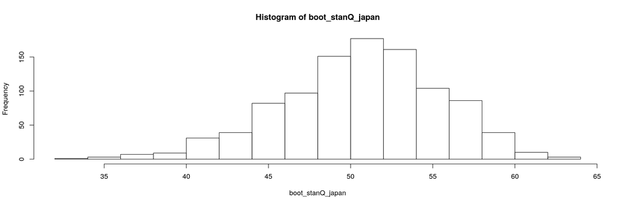

```r
stan_Q  <- function (x) {
  mean <- mean(null_swap_whole_japan[,2])
  sd <- sd(null_swap_whole_japan[,2])
  y <- (x)
  result <- (y-mean)/sd
}
j_w_value_q <- sapply(index_whole_japan[,3], stan_Q) #real standardized value
boot_stanQ_japan <- as.numeric(sapply(boot_whole_japan[,3], stan_Q)) #bootstrap standardized values
#write.csv2(boot_stanQ_japan, file = "boot_stanQ_japan.csv")
hist(boot_stanQ_japan)
```

## Statistical analysis: MANN - WHITNEY TEST

Statistical differences of the three indices between the native and invaded areas were tested by means of non-parametric Mann-Whitney-Wilcoxon tests.

```r
# C
wilcox.test(index_whole_azov[,1], index_whole_japan[,1], conf.int = TRUE, conf.level = 0.95)
```

```
##
##  Wilcoxon rank sum test
##
## data:  index_whole_azov[, 1] and index_whole_japan[, 1]
## W = 0, p-value = 1
## alternative hypothesis: true location shift is not equal to 0
## 0 percent confidence interval:
##  -0.187954 -0.187954
## sample estimates:
## difference in location
##              -0.187954
```

```r
# WNODF
wilcox.test(null_swap_whole_azov[,1], null_swap_whole_japan[,1], conf.int = TRUE, conf.level = 0.95)
```

```
##
##  Wilcoxon rank sum test with continuity correction
##
## data:  null_swap_whole_azov[, 1] and null_swap_whole_japan[, 1]
## W = 0, p-value < 2.2e-16
## alternative hypothesis: true location shift is not equal to 0
## 95 percent confidence interval:
##  -22.49123 -22.27829
## sample estimates:
## difference in location
##              -22.38482
```

```r
# Q
wilcox.test(null_swap_whole_azov[,2], null_swap_whole_japan[,2], conf.int = TRUE, conf.level = 0.95)
```

```
##
##  Wilcoxon rank sum test with continuity correction
##
## data:  null_swap_whole_azov[, 2] and null_swap_whole_japan[, 2]
## W = 1e+06, p-value < 2.2e-16
## alternative hypothesis: true location shift is not equal to 0
## 95 percent confidence interval:
##  0.2214178 0.2229046
## sample estimates:
## difference in location
##              0.2221765
```

### Statistical metrics of the values of the indices of the Sea of Azov

We collected the real value, mean, standard deviation, and 95% confidence intervals of the indices for both areas.

```r
# SEA OF AZOV
## C VALUES
a_whole_value_c <- index_whole_azov[,1] #real value
a_whole_mean_c <- mean(boot_whole_azov[,1])
a_whole_sd_c <- sd(boot_whole_azov[,1])
a_whole_ci_c <- quantile(boot_whole_azov[,1], c(0.025,0.975))

## WNODF VALUES
a_whole_value_wnodf <- sapply(index_whole_azov[,2], stan_WNODF) #real standardized value
a_whole_mean_wnodf <- mean(boot_stanWNODF_azov)
a_whole_sd_wnodf <- sd(boot_stanWNODF_azov)
a_whole_ci_wnodf <- quantile(boot_stanWNODF_azov, c(0.025,0.975))

## Q VALUES
a_whole_value_q <- sapply(index_whole_azov[,3], stan_Q) #real standardized value
a_whole_mean_q <- mean(boot_stanQ_azov)
a_whole_sd_q <- sd(boot_stanQ_azov)
a_whole_ci_q <- quantile(boot_stanQ_azov, c(0.025,0.975))


# SEA OF JAPAN
## C VALUES
j_whole_value_c <- index_whole_japan[,1] #real value
j_whole_mean_c <- mean(boot_whole_japan[,1])
j_whole_sd_c <- sd(boot_whole_japan[,1])
j_whole_ci_c <- quantile(boot_whole_japan[,1], c(0.025,0.975))

## WNODF VALUES
j_whole_value_wnodf <- sapply(index_whole_japan[,2], stan_WNODF) #real standardized value
j_whole_mean_wnodf <- mean(boot_stanWNODF_japan)
j_whole_sd_wnodf <- sd(boot_stanWNODF_japan)
j_whole_ci_wnodf <- quantile(boot_stanWNODF_japan, c(0.025,0.975))

## Q VALUES
j_whole_value_q <- sapply(index_whole_japan[,3], stan_Q) #real standardized value
j_whole_mean_q <- mean(boot_stanQ_japan)
j_whole_sd_q <- sd(boot_stanQ_japan)
j_whole_ci_q <- quantile(boot_stanQ_japan, c(0.025,0.975))


## Create a data frame with all the index results

a_whole_connectance <- c(a_whole_value_c, a_whole_mean_c, a_whole_sd_c, a_whole_ci_c)
j_whole_connectance <- c(j_whole_value_c, j_whole_mean_c, j_whole_sd_c, j_whole_ci_c)

a_whole_wnodf <-c(a_whole_value_wnodf, a_whole_mean_wnodf, a_whole_sd_wnodf, a_whole_ci_wnodf)
j_whole_wnodf <-c(j_whole_value_wnodf, j_whole_mean_wnodf, j_whole_sd_wnodf, j_whole_ci_wnodf)

a_whole_q <-c(a_whole_value_q, a_whole_mean_q, a_whole_sd_q, a_whole_ci_q)
j_whole_q <- c(j_whole_value_q, j_whole_mean_q, j_whole_sd_q, j_whole_ci_q)

whole_values <- rbind(a_whole_connectance, j_whole_connectance, a_whole_wnodf, j_whole_wnodf, a_whole_q, j_whole_q)
colnames(whole_values) <- c("value", "mean", "sd", "ci_min", "ci_max")
whole_values
```

```
##                          value        mean          sd      ci_min      ci_max
## a_whole_connectance   0.132178   0.1335396 0.004046527   0.1266487   0.1423486
## j_whole_connectance   0.320132   0.3310885 0.015029720   0.3081035   0.3634836
## a_whole_wnodf       -17.653624  -2.9588705 1.501064467  -5.8348379  -0.1067442
## j_whole_wnodf       -14.040982 -14.1287911 1.054582973 -16.1620536 -12.0879211
## a_whole_q            81.585851  28.5240211 3.732869060  19.4791747  33.8998347
## j_whole_q            51.577549  50.6413682 4.815969152  40.6171716  59.3625889
```